# Project 1 for ST558

Annie Brinza

2022-09-09

## Data Processing

### First Steps

I read the relevant first data set in and manipulated it into the right format with the right columns.

```r
library(readr)
library(tidyverse)
sheet1 <- read_csv("https://www4.stat.ncsu.edu/~online/datasets/EDU01a.csv", show_col_types = FALSE)

# Selecting several columns
sheet1_limited <- sheet1 %>%
                    select("Area_name", "STCOU", ends_with("D")) %>%
                      rename(area_name = Area_name)

# Converting data into long format, where each row only has one enrollment value for that area_name
sheet1_long <- sheet1_limited %>%
                pivot_longer(cols = 3:12, names_to = "edu" ,values_to = "enrollment")

# Retrieving year and type of measurement
sheet1_long <- sheet1_long %>%
                mutate(year = as.numeric(paste("19", substr(edu, 8, 9), sep = "")),
                       measurement_type = substr(edu, 1, 7))

# Splitting data set into two - one for county-level, and one for non-county level data
# For the county-level data, we know it has to contain a comma since they all have the format County Name, DD
# Also adding in the county and state the data belongs to for the county
county_tibble <- sheet1_long %>%
                filter(grepl(",", area_name)) %>%
                  mutate(state = sub(".*, ", "", area_name))
class(county_tibble) <- c("county", class(county_tibble))

# For the non-county level, we know if it contains a comma, it is a county level row
non_county_tibble <- sheet1_long %>%
                filter(!grepl(",", area_name)) %>%
                  mutate(division = ifelse(area_name == "CONNECTICUT" | area_name =="MAINE" | area_name == "MASSACHUSETTS" | area_name == "NEW HAMPSHIRE" | area_name == "RHODE ISLAND" | area_name == "VERMONT", "New England", ifelse(area_name == "NEW JERSEY" | area_name == "NEW YORK" | area_name == "PENNSYLVANIA", "Mid-Atlantic", ifelse(area_name == "ILLINOIS" | area_name == "INDIANA" | area_name == "MICHIGAN" | area_name == "OHIO" | area_name == "WISCONSIN", "East North Central", ifelse(area_name == "IOWA" | area_name == "KANSAS" | area_name == "MINNESOTA" | area_name == "MISSOURI" | area_name == "NEBRASKA" | area_name == "NORTH DAKOTA" | area_name == "SOUTH DAKOTA", "West North Central", ifelse(area_name == "DELAWARE" | area_name == "FLORIDA" | area_name == "GEORGIA" | area_name == "MARYLAND" | area_name == "NORTH CAROLINA" | area_name == "SOUTH CAROLINA" | area_name == "VIRGINIA" | area_name == "WEST VIRGINIA" | area_name == "District of Columbia" | area_name == "DISTRICT OF COLUMBIA", "South Atlantic", ifelse(area_name == "ALABAMA" | area_name == "KENTUCKY" | area_name == "MISSISSIPPI" | area_name == "TENNESSEE", "East South Central", ifelse(area_name == "ARKANSAS" | area_name == "LOUISIANA" | area_name == "OKLAHOMA" | area_name == "TEXAS", "West South Central", ifelse(area_name == "ARIZONA" | area_name == "COLORADO" | area_name == "IDAHO" | area_name == "MONTANA" | area_name == "NEVADA" | area_name == "NEW MEXICO" | area_name == "UTAH" | area_name == "WYOMING", "Mountain", ifelse(area_name == "ALASKA" | area_name == "CALIFORNIA" | area_name == "HAWAII" | area_name == "OREGON" | area_name == "WASHINGTON", "Pacific", "ERROR"))))))))))

class(non_county_tibble) <- c("state", class(non_county_tibble))
```

### Requirements

Now I’m going to repeat the above process for the second component of the data set. I am going to do this using functions that can do each of the individual above pieces, and then I am going to create a single function that can be called to do it all.

I created some helper functions to aid in the main functions, so I will show those first

```r
# A function to read in a csv
read_csv_code <- function(url){
  sheet1 <- read_csv(url, show_col_types = FALSE)
}
```

```r
# Writing the functions to do the individual pieces

# Starting with selecting columns and converting the data into long format
select_columns_convert_data <- function(df, columns_names_to, value_col = "enrollment"){
  df_limited <- df %>% select("Area_name", "STCOU", ends_with("D")) %>% rename(area_name = Area_name)
  df_long <- df_limited %>% pivot_longer(3:12, names_to = columns_names_to, values_to = value_col)
  }

# Creating a function to extract year and measurement type from the pivoted column
create_year_and_measurement_cols <- function(df, year_column){
  df <- df %>% mutate(year = as.numeric(paste("19", substr(edu, 8, 9), sep = "")), measurement_type = substr(year_column, 1, 7))
}

# Creating a function to describe which state the county measurements correspond to
extract_state <- function(x, separator){
  state <-  sub(separator, "", x)
}

# Creating a function to create the divisions
create_state_divisions <- function(x){
  division <- ifelse(x == "CONNECTICUT" | x =="MAINE" | x == "MASSACHUSETTS" | x == "NEW HAMPSHIRE" | x == "RHODE ISLAND" | x == "VERMONT", "New England", ifelse(x == "NEW JERSEY" | x == "NEW YORK" | x == "PENNSYLVANIA", "Mid-Atlantic", ifelse(x == "ILLINOIS" | x == "INDIANA" | x == "MICHIGAN" | x == "OHIO" | x == "WISCONSIN", "East North Central", ifelse(x == "IOWA" | x == "KANSAS" | x == "MINNESOTA" | x == "MISSOURI" | x == "NEBRASKA" | x == "NORTH DAKOTA" | x == "SOUTH DAKOTA", "West North Central", ifelse(x == "DELAWARE" | x == "FLORIDA" | x == "GEORGIA" | x == "MARYLAND" | x == "NORTH CAROLINA" | x == "SOUTH CAROLINA" | x == "VIRGINIA" | x == "WEST VIRGINIA" | x == "District of Columbia" | x == "DISTRICT OF COLUMBIA", "South Atlantic", ifelse(x == "ALABAMA" | x == "KENTUCKY" | x == "MISSISSIPPI" | x == "TENNESSEE", "East South Central", ifelse(x == "ARKANSAS" | x == "LOUISIANA" | x == "OKLAHOMA" | x == "TEXAS", "West South Central", ifelse(x == "ARIZONA" | x == "COLORADO" | x == "IDAHO" | x == "MONTANA" | x == "NEVADA" | x == "NEW MEXICO" | x == "UTAH" | x == "WYOMING", "Mountain", ifelse(x == "ALASKA" | x == "CALIFORNIA" | x == "HAWAII" | x == "OREGON" | x == "WASHINGTON", "Pacific", "ERROR")))))))))
}

# Creating a function to create county level and non-county level tibbles
create_county_non_county_tibbles <- function(df){
  county_tibble <- df %>% filter(grepl(",", area_name)) %>%
                            mutate(state = extract_state(area_name, separator = ".*, "))
  class(county_tibble) <- c("county", class(county_tibble))

  non_county_tibble <- df %>% filter(!grepl(",", area_name)) %>%
                              mutate(division = create_state_divisions(area_name))
  class(non_county_tibble) <- c("state", class(non_county_tibble))

  list(county_tibble, non_county_tibble)
}

# Creating a wrapper function
modify_education_data <- function(url, variable_name = "enrollment"){
  df <- read_csv_code(url)
  df_long <- select_columns_convert_data(df, columns_names_to = "edu", value_col = variable_name)
  df_new_vars <- create_year_and_measurement_cols(df_long, year_column = "edu")
  county_non_county_tibbles <- create_county_non_county_tibbles(df_new_vars)
}
```

### Combining Data

Now that I’ve created all the functions and the wrapper function, it’s time to put everything together! I will call my wrapper function twice to read in and parse the two `.csv` files mentioned so far.

```r
# Calling the function for both urls
url1 <- modify_education_data("https://www4.stat.ncsu.edu/~online/datasets/EDU01a.csv", "enrollment")
url2 <- modify_education_data("https://www4.stat.ncsu.edu/~online/datasets/EDU01b.csv", "enrollment")

# Creating a function that takes in the results of the two calls and combines the tibbles appropriately
combining_tibbles <- function(x, y){
  county_tibbles <- dplyr::bind_rows(x[1], y[1])
  non_county_tibbles <- dplyr::bind_rows(x[2], y[2])
  list(county_tibbles, non_county_tibbles)
}

combined_data <- combining_tibbles(url1, url2)
```

## Writing a Generic Function for Summarizing

I am going to create my own custom plot function since I created two new classes of county and state. First I will create a state plotting method that plots the mean value of the statistic across the years for each `division`.

```r
# First creating a state plotting method that plots the mean value of the statistic across the years for each division
plot.state <- function(df, var_name = "enrollment"){
  means_division_year <- df %>%
                          filter(division != "ERROR") %>%
                            group_by(year, division) %>%
                              summarise(mean_div_year = mean(get(var_name)))
  #Use get(var_name) to reference the var_name in your call to mean(): mean(get(var_name))
  #For this, think group_by along with summarize (we did mutate in class, summarize is very similar)
  #remove the "ERROR" setting
  ggplot(means_division_year, aes(x = year, y = mean_div_year, color = division)) +
  geom_line()
}
```

Next, I will create a more flexible county plotting method that allows the user to specify the state of interest, determine whether top or bottom most counties should be looked at, with the additional option of choosing how many top or bottom counties will be investigated.

```r
# Creating the county custom plotting method
plot.county <- function(df, state_choice = "NM", top_or_bottom = "top", number_of = 5, var_name = "enrollment"){
  df_new <- df %>%
              filter(state == state_choice) %>%
                group_by(area_name) %>%
                  summarize(mean_val = mean(get(var_name)), top_or_bottom_col = top_or_bottom) %>%
                    arrange(ifelse(top_or_bottom_col == "top", desc(mean_val), ifelse(top_or_bottom == "bottom", mean_val, stop("Please select only top or bottom"))))

  relevant_counties <- head(df_new, number_of)
  filtered_df <- df %>% filter(area_name %in% relevant_counties$area_name)

  ggplot(filtered_df, aes(x = year, y = get(var_name), color = area_name)) +
  geom_line()
}
```

### Putting it All Together!

Now that all functions have been written, it’s time to put the whole shebang together. The data processing function will be run on the two enrollment URLs, the resulting data frames will be put into one object. Then we will plot state and county, choosing several options for the county plotting method.

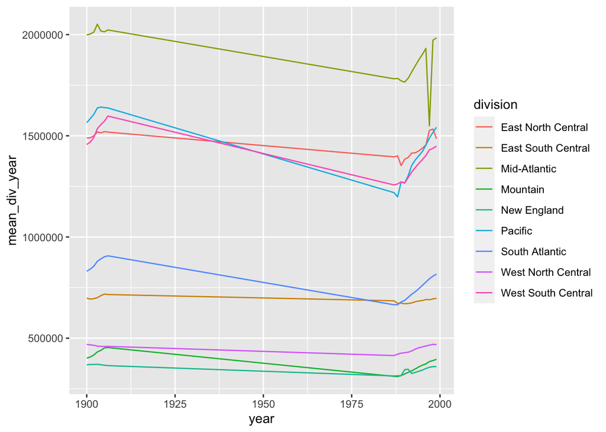

```r
# Calling the function for both urls
url1 <- modify_education_data("https://www4.stat.ncsu.edu/~online/datasets/EDU01a.csv", "enrollment")
url2 <- modify_education_data("https://www4.stat.ncsu.edu/~online/datasets/EDU01b.csv", "enrollment")

# Combining the data appropriately
combined_data_enrollment <- combining_tibbles(url1, url2)

# Plotting state
plot.state(combined_data_enrollment[[2]], var_name = "enrollment")
```

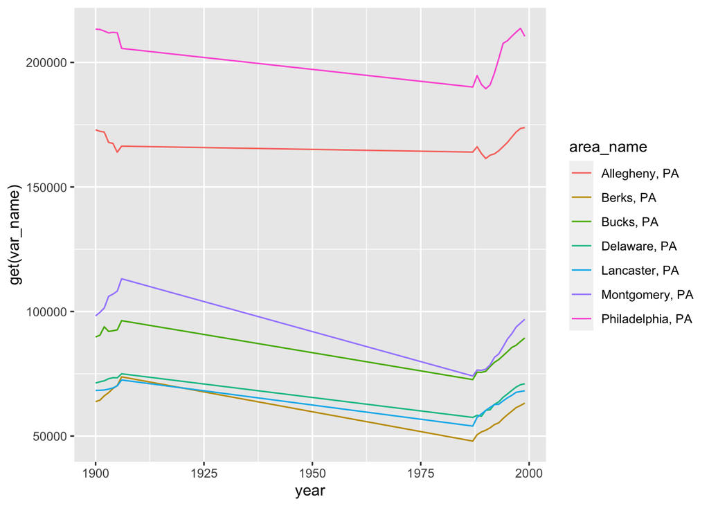

```r
# Plotting county
# First for PA, top group, 7 topmost counties
plot.county(combined_data_enrollment[[1]], state_choice = "PA", top_or_bottom = "top", number_of = 7, var_name = "enrollment")
```

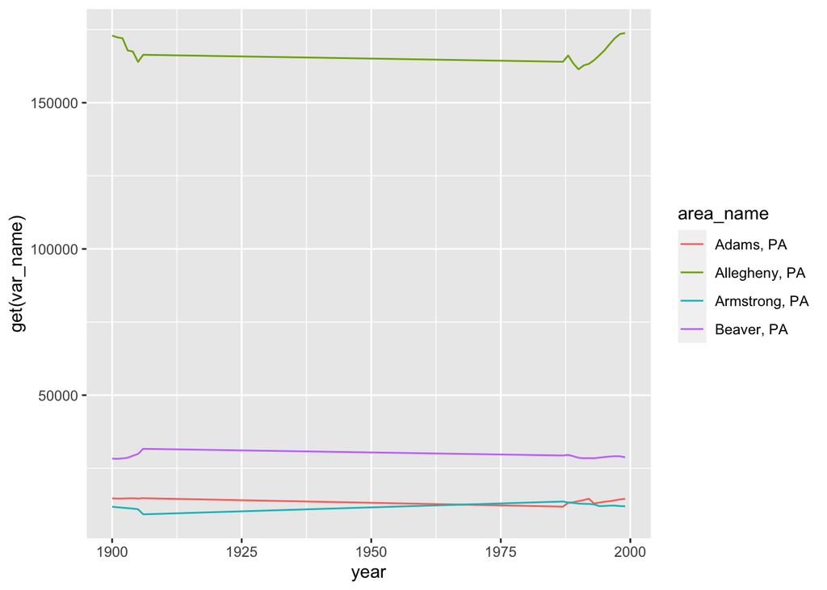

```r
# Next for PA, bottom group, 4 bottommost counties
plot.county(combined_data_enrollment[[1]], state_choice = "PA", top_or_bottom = "bottom", number_of = 4, var_name = "enrollment")
```

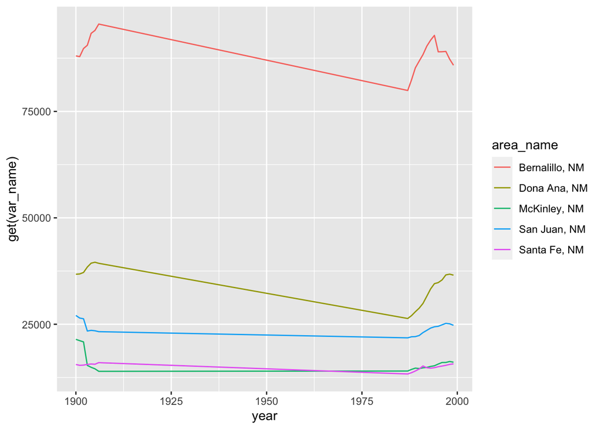

```r
# Next with just the defaults
plot.county(combined_data_enrollment[[1]])
```

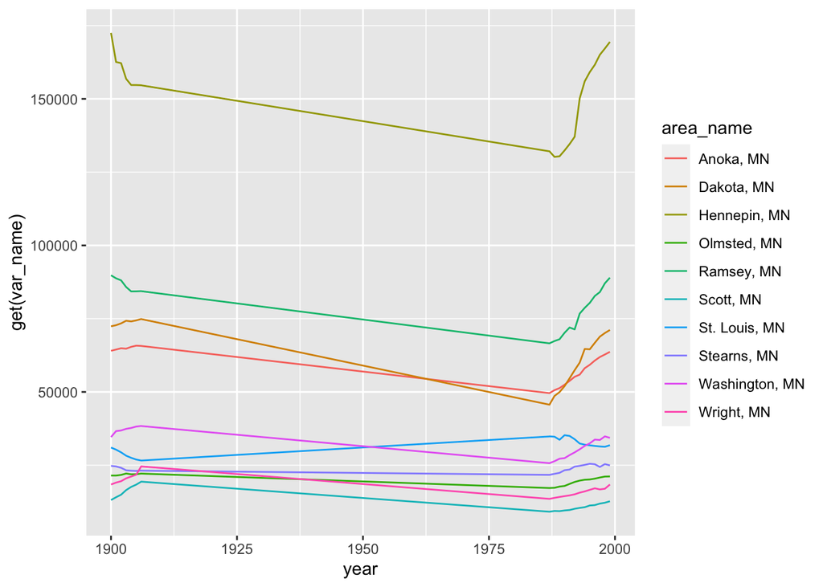

```r
# Finally with MN, top group, topmost 10 counties
plot.county(combined_data_enrollment[[1]], state_choice = "MN", top_or_bottom = "top", number_of = 10, var_name = "enrollment")
```

Last of all, I will read in a new, yet similar, data set and apply these shiny new functions to it. There are four URLs to be used this time. The main variable here to consider is the total resident population, so the variable name will be updated accordingly.

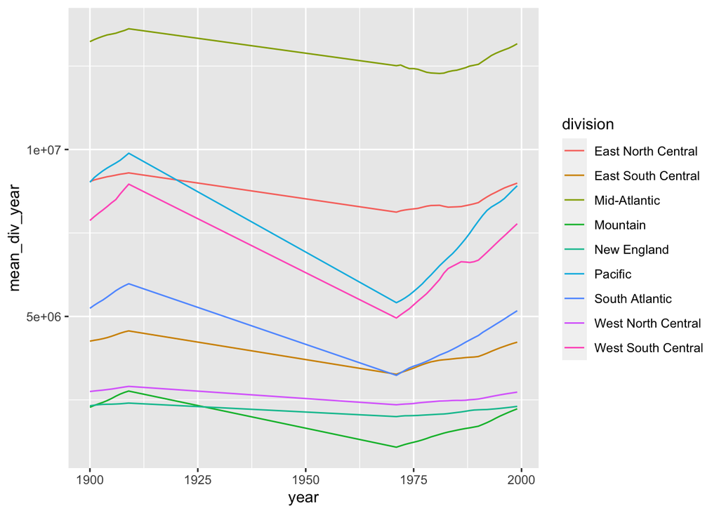

```r
# Calling the data processing function on the new URLs
url1 <- modify_education_data("https://www4.stat.ncsu.edu/~online/datasets/PST01a.csv", "total_resident_pop")
url2 <- modify_education_data("https://www4.stat.ncsu.edu/~online/datasets/PST01b.csv", "total_resident_pop")
url3 <- modify_education_data("https://www4.stat.ncsu.edu/~online/datasets/PST01c.csv", "total_resident_pop")
url4 <- modify_education_data("https://www4.stat.ncsu.edu/~online/datasets/PST01d.csv", "total_resident_pop")

# Combining the data appropriately
combined_data1 <- combining_tibbles(url1, url2)
combined_data2 <- combining_tibbles(combined_data1, url3)
combined_data_pop <- combining_tibbles(combined_data2, url4)

# Plotting state
plot.state(combined_data_pop[[2]], var_name = "total_resident_pop")
```

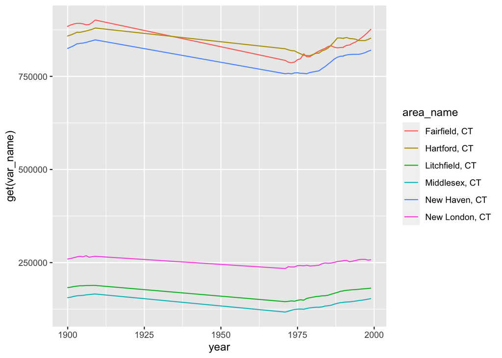

```r
# Plotting county
# First for CT, top group, 6 topmost counties
plot.county(combined_data_pop[[1]], state_choice = "CT", top_or_bottom = "top", number_of = 6, var_name = "total_resident_pop")
```

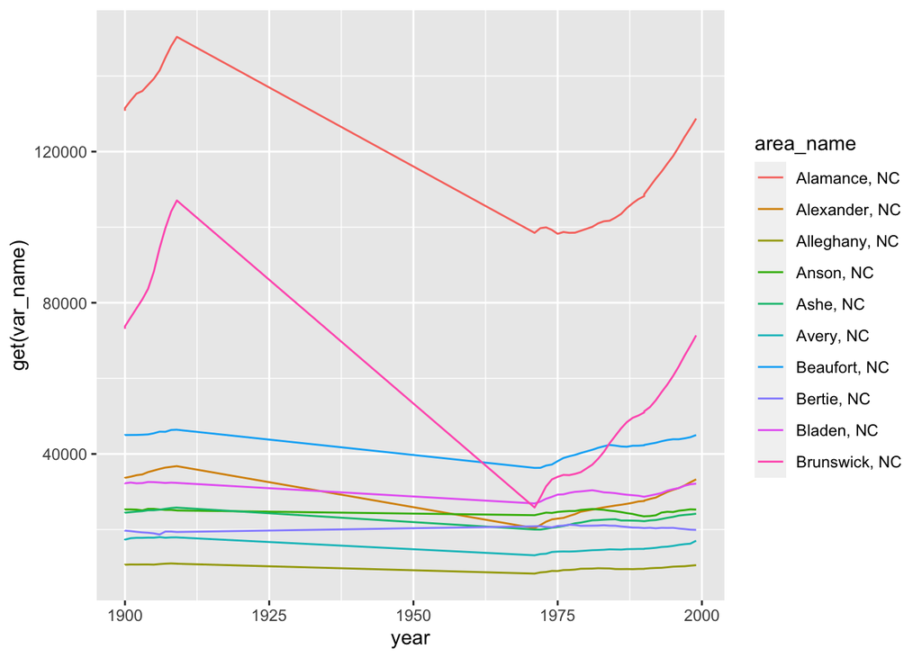

```r
# Next for NC, bottom group, 10 bottommost counties
plot.county(combined_data_pop[[1]], state_choice = "NC", top_or_bottom = "bottom", number_of = 10, var_name = "total_resident_pop")
```

```r
# Next with the defaults
plot.county(combined_data_pop[[1]])
```

```
## Error in `summarize()`:
## ! Problem while computing `mean_val = mean(get(var_name))`.
## ℹ The error occurred in group 1: area_name = "Bernalillo, NM".
## Caused by error in `get()`:
## ! object 'enrollment' not found
```

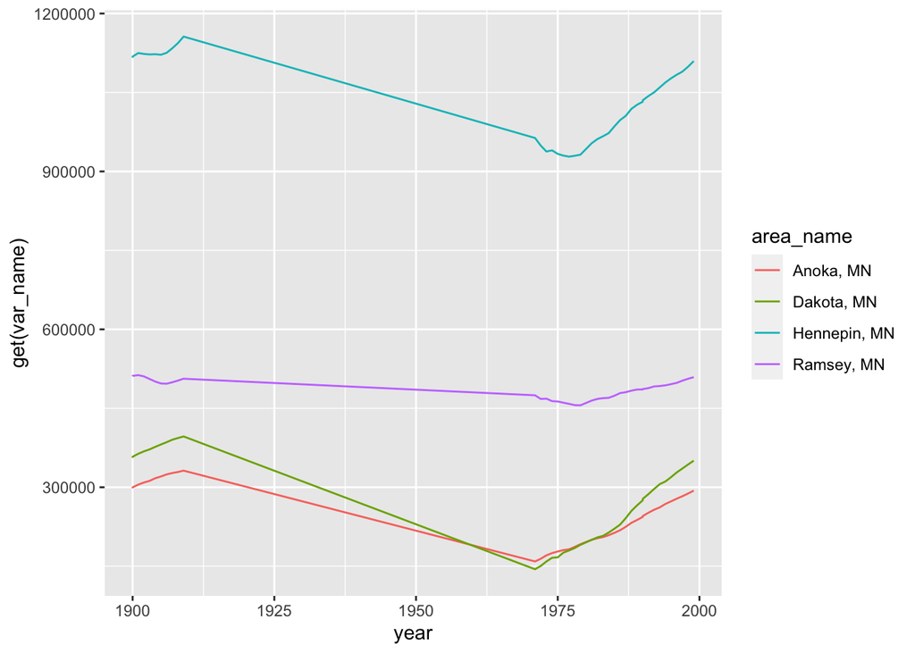

```r
# Last for MN, top group, 4 topmost counties
plot.county(combined_data_pop[[1]], state_choice = "MN", top_or_bottom = "top", number_of = 4, var_name = "total_resident_pop")
```